# Part II - Factors affecting bike sharing: A case study of Ford GoBike Share

## by Emenike Goodluck

## Investigation Overview

> I was interested to find out when are most trips taken in terms of time of day, day of the week, or month of the year? How long does the average trip take? Does the above depend on if a user is a subscriber or customer? And how the trip is affected based on the user type, age and gender.

## Dataset Overview

> There are 183412 riders recorded in the Ford GoBike Share dataset with 17 columns of which `start time`, `duration_sec`, `birth_year`, and `bike_share_for_all_trip` are important columns for this analysis. After cleaning the dataset I analyzed 174952 riders which represent 95% of the original dataset. The following additional columns - `distance_meters`, `speed_mps`, `hour`, `day`, and `day_name` were created to aid the analysis.

> The users are categorized as either `customer` or `subscriber`

> Three genders participated `male`, `female` and `other` and some participants shared their rides during the trip

## Most of the participants are below 40 years old

> Most of the participants are between the ages of 25 and 35.

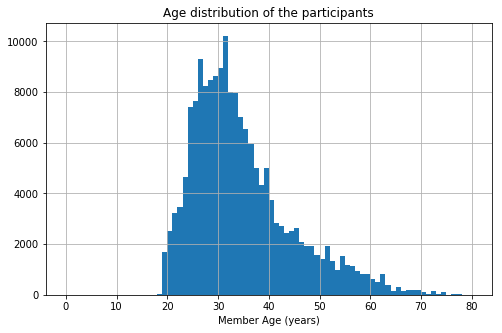

## Gender distribution

> Majority of the participants are male

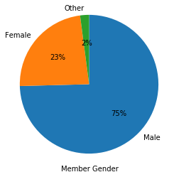

## Most of the trips were made at 08 hrs and 17 hours most of the days

> Of the days of the month, day 28 at 08hrs had the highest number of participants. Also, most of the rides were made at 08 hrs and 17 hrs everyday.

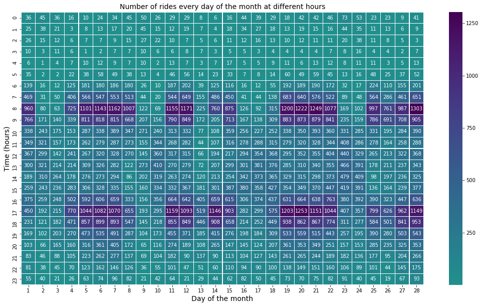

## Saturdays and Sundays had the least amount of rides

> Most of the trips was taken on Thursdays at 17 hrs. Of all the days of the week, Saturdays and Sundays had the least number of participants and more participants turned up on weekdays.

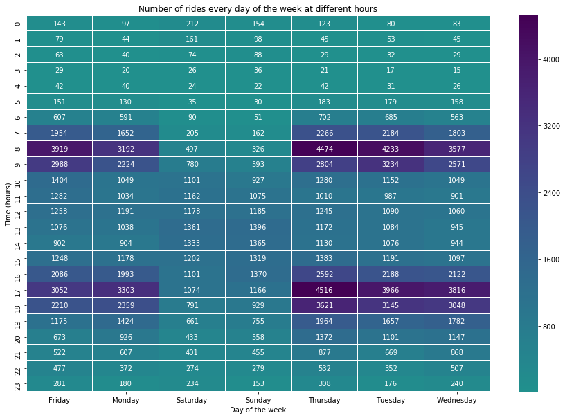

## Customers did not share their rides and younger subscribers shared their rides more

> None of the customers shared their rides. Most of the subscribers that shared their rides are young compared to the ones that did not share their rides.

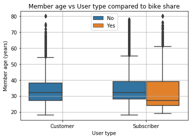